# slide_deck_template slides

## Mohammed Al Mujadib

## Project : Ford GoBike Data Explanation

## Investigation Overview:

**The presentation shows the most user type, who of these users will finish the trip faster, and why the finish it faster.**

## Dataset Overview:

**GoFord bike System data about the bike trips in 2019, with some attributes such as users type and duration of trips and more. Data already cleaned in the wrangling phase.**

```python
df_clean = pd.read_csv('df_file.csv')
df_clean.head()
```

|  | duration_sec | start_time | end_time | start_station_id | start_station_name | start_station_latitude | start_station_longitude | end_station_id | end_station_name | end_station_latitude | end_station_longitude | bike_id | user_type | member_birth_year | member_gender | bike_share_for_all_trip | duration_min |
| --- | --- | --- | --- | --- | --- | --- | --- | --- | --- | --- | --- | --- | --- | --- | --- | --- | --- |
| 0 | 1585 | 2019-02-28 23:54:18.549 | 2019-03-01 00:20:44.074 | 7.0 | Frank H Ogawa Plaza | 37.804562 | -122.271738 | 222.0 | 10th Ave at E 15th St | 37.792714 | -122.248780 | 4898 | Subscriber | 1974.0 | Male | Yes | 26 |
| 1 | 1793 | 2019-02-28 23:49:58.632 | 2019-03-01 00:19:51.760 | 93.0 | 4th St at Mission Bay Blvd S | 37.770407 | -122.391198 | 323.0 | Broadway at Kearny | 37.798014 | -122.405950 | 5200 | Subscriber | 1959.0 | Male | No | 29 |
| 2 | 1615 | 2019-02-28 23:41:06.766 | 2019-03-01 00:08:02.756 | 10.0 | Washington St at Kearny St | 37.795393 | -122.404770 | 127.0 | Valencia St at 21st St | 37.756708 | -122.421025 | 6329 | Subscriber | 1989.0 | Male | No | 26 |
| 3 | 1570 | 2019-02-28 23:41:48.790 | 2019-03-01 00:07:59.715 | 10.0 | Washington St at Kearny St | 37.795393 | -122.404770 | 127.0 | Valencia St at 21st St | 37.756708 | -122.421025 | 6548 | Subscriber | 1988.0 | Other | No | 26 |
| 4 | 1049 | 2019-02-28 23:49:47.699 | 2019-03-01 00:07:17.025 | 19.0 | Post St at Kearny St | 37.788975 | -122.403452 | 121.0 | Mission Playground | 37.759210 | -122.421339 | 6488 | Subscriber | 1992.0 | Male | No | 17 |

## What are the most user type?

**The chart shows what are the most user type that we have in our dataset, and the most user type we have is the Subscribers**

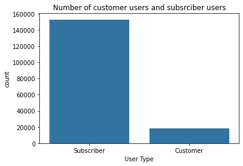

```python
df_color = sb.color_palette()[0]
sb.countplot(data = df_clean, x = 'user_type', color = df_color);
plt.xlabel('User Type');
plt.title('Number of customer users and subsrciber users');
```

## What type of users is faster on finishing the trip?

**This plot shows who are the user type that finishes the trip faster, and it is looks like the subsrcibers is faster than the Customers**

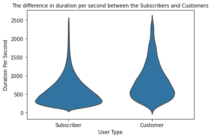

```python
sb.violinplot(data = df_clean, x = 'user_type', y = 'duration_sec',color = df_color, inner = None);
plt.title('The difference in duration per second between the Subscribers and Customers', size = 10);
plt.xlabel('User Type')
plt.ylabel('Duration Per Second');
```

## Why the subscribers is faster than the customers?

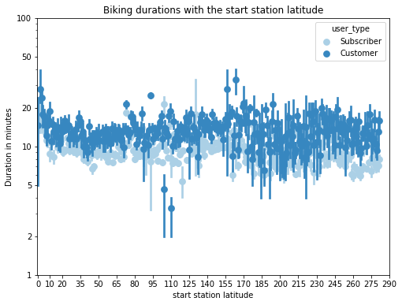

```python
fig = plt.figure(figsize = [8,6]);
ax = sb.pointplot(data = df_clean, x = 'start_station_latitude', y = 'duration_min', hue = 'user_type',
           palette = 'Blues', linestyles = '');
plt.title('Biking durations with the start station latitude')
plt.xlabel('start station latitude')
plt.ylabel('Duration in minutes')
plt.yscale('log')
plt.yticks([1, 2, 5, 10, 20, 50, 100], [1, 2, 5, 10, 20, 50, 100]);
plt.xticks([0,10,20,35,50,65,80,95,110,125,140,155,170,185,200,215,230,245,260,275,290],[0,10,20,35,50,65,80,95,110,125,140,155,170,185,200,215,230,245,260,275,290]);
ax.set_yticklabels([],minor = True);
```

## Why the subscribers is faster than the customers?

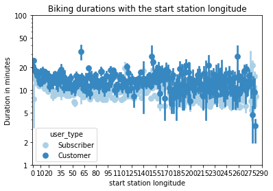

```python
ax = sb.pointplot(data = df_clean, x = 'start_station_longitude', y = 'duration_min', hue = 'user_type',
           palette = 'Blues', linestyles = '');
plt.title('Biking durations with the start station longitude')
plt.xlabel('start station longitude')
plt.ylabel('Duration in minutes')
plt.yscale('log')
plt.yticks([1, 2, 5, 10, 20, 50, 100], [1, 2, 5, 10, 20, 50, 100]);
plt.xticks([0,10,20,35,50,65,80,95,110,125,140,155,170,185,200,215,230,245,260,275,290],[0,10,20,35,50,65,80,95,110,125,140,155,170,185,200,215,230,245,260,275,290]);
ax.set_yticklabels([],minor = True);
```